# ラテンキューブ・レポート2020/1/11

サイズ7のラテンキューブの個数推定を行った．

- 今回の計算ではエネルギーの変更・候補提案方法の変更を行った．
- その結果収束したように見えるのでレポートにまとめる．

# 1 結果

個数推定値は$1.11647\times 10^{23} \sim 1.19915\times 10^{23}$であった．

以下に初期状態から始めた収束プロットを示す．

- 初期状態とは一番普通のラテンキューブである．つまり1行1列目の高さベクトルが$1,2,\ldots,L$で， それ以外の高さベクトルは隣と一つシンボルをずらした順列となるラテンキューブである．
- レプリカ数98，$\beta=2.5$．
- $10^4$MCS計算するごとにサンプルをとる．およそ$9.8\times 10^6$サンプル取得した．
- 個別のサンプルによる推定値を青のドットで表す．
- サンプル平均による推定値をオレンジの線で示す．
- 収束したように見えるが，その後突然収束状況が変わる場面が何度も見られる．

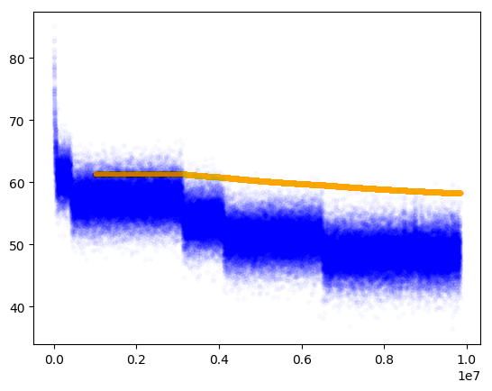

以下に上記プロットの最終状態を初期値とする収束プロットを示す．

- 一つ上の収束状況に移ろうとするときがあるが，結局この収束状況にとどまっている．
- 平均はこのプロットから計算した．（つまり上記プロットの計算結果を含まない）
- 他に5回計算した．それらのプロットは付録に示した．

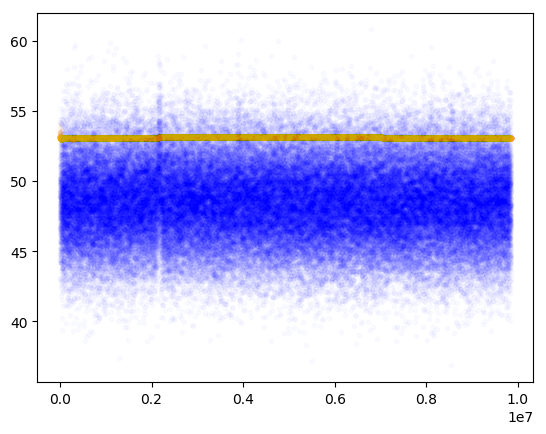

# 2 展望

収束した保証がないので，異なる計算方法でも同様の推定値が得られることを確認したい．

- 別の計算の候補として，ラテンキューブの対称性により分類したクラスごとの個数推定を検討する．それらの合計値が同様の値になればまず安心だろう．
- それが大変だとしたら，エネルギーの変更・レプリカ数の変更・逆温度$\beta$の変更などを行っても 同様の推定値が得られることを確認する．

今回の計算は統数研のスパコンで一週間かかったので，GPUなどを使って1日ですませられないか検討する．

# 3 変更点の説明

今回の個数推定では候補提案方法の変更・エネルギーの変更を行った．それぞれ説明する．

## 3.1 エネルギー

各状態は3次元配列であり，各状態のエネルギーは各行・各列・各高さベクトルのエネルギーの和である．

- エネルギーは各ベクトルがシンボルの順列からどれだけ離れているかを示す．
- 順列のエネルギーは0でなければならない．

今までエネルギーには$l^1$ノルムを使っていた．

- $v$を各行・各列・各高さを表すベクトルとして， $n_i$を$v$の中のシンボル$i$の個数とする． このとき$l^1$ノルムは，
  $$\|v\|_{l^1} = \sum_{i=1}^L |n_i -1|$$
  と表せる．

今回使用したエネルギーは$l^0$ノルムである．すなわち
$$\|v\|_{l^0} = |n_i=1となるiの個数 - L|$$
である．

- なぜ$l^0$ノルムを選んだかというと， 以前スパース推定の講義で，$l^0$ノルムの方が$l^1$ノルムより計算は大変だが性質はよい，と聞いた気がするからである．
- 他にも$l^2$ノルム（$\sum_{i=1}^L (n_i-1)^2$），0ノルム（$n_i=0$となる$i$の個数）など様々なものが考えられる．
- MCMCで利用するエネルギーは，収束が速いことに加えて計算速度が速いことが重要である．

## 3.2 候補提案方法

今まで候補提案は，各高さベクトルに対して，その成分2つをランダムに選び交換した順列を候補としていた．

- そのため現在の高さベクトルと候補の高さベクトルとは相関が強かった．
- この候補提案を使っていたのは，ラテン方陣の個数推定で使われていたからである．
- またこの候補ならばエネルギー変化量の計算が容易だからである．

今回の候補提案は，高さベクトルが取りうるすべての順列からランダムに選び提案する．

- サイズ7だから候補は高々$7!=$ 5040通り以下であり，そのためこの提案方法が可能となる．

# 4 付録

## 4.1 サイズ6の収束

参考として今回の計算方法を使ったサイズ6の収束プロットを挙げる．

- レプリカ数72，$\beta=2.5$．
- 収束状況の突然の変化は見られない．

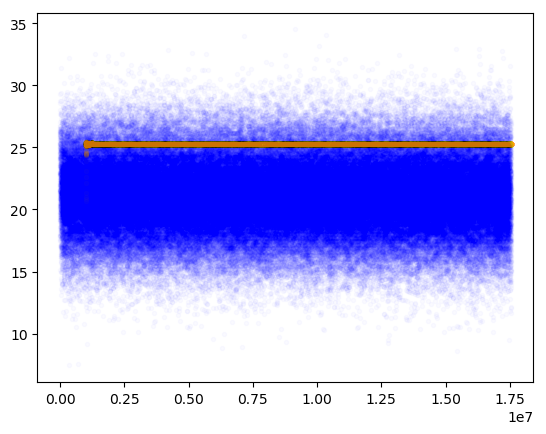

- 真の値の対数25.28668，真の値9.59099e+10
- 計算値の対数25.27804，計算値9.50851e+10
- 真の値との差はあまりよくなく$8.6\times 10^{-3}$程度であった．

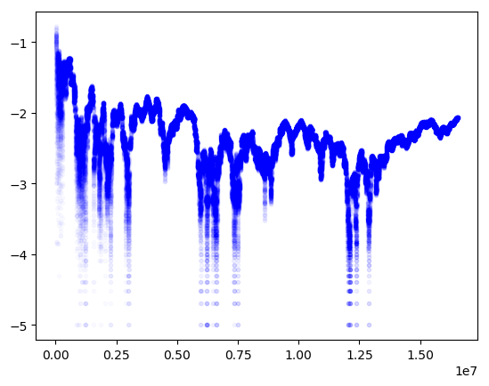

## 4.2 サイズ7の収束プロットその他

1で示したサイズ7の計算は他にも5回行ったので，それらの収束プロットを示す．

- 一つ上の収束状況に移ろうとするときがあるが，結局どれもこの収束状況にとどまっているようである．

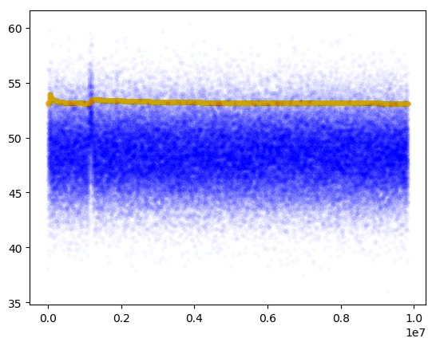

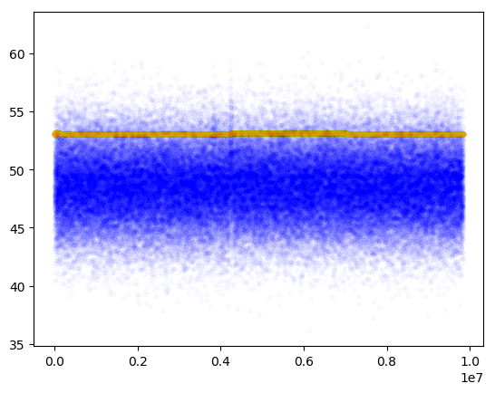

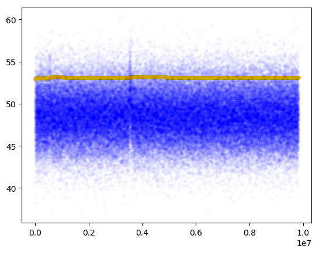

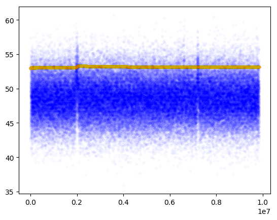

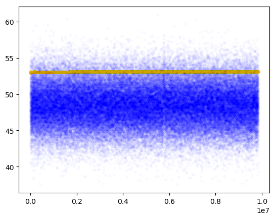

## 4.3 過去レポートの収束プロット

- 2019年5月のレポートでは$3\times 10^9$MCS計算していたが，これでは計算量が足りなかった．

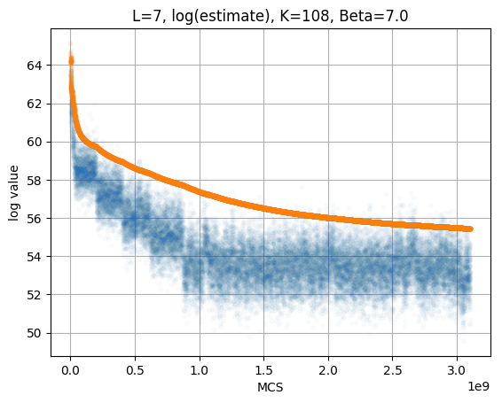